# Assignment 4: Pharmaceutical Industry Clustering

Conor Mangan

2026-10-21

# 1 Introduction

The purpose of this assignment is to use k-means clustering to explore the financial characteristics of 21 companies in the pharmaceutical industry. Cluster analysis is an unsupervised machine learning technique that identifies groups of observations with similar characteristics without requiring a predetermined outcome variable.

The analysis uses nine financial measures to identify similarities and differences among pharmaceutical companies. The resulting clusters are then evaluated using median brokerage recommendations, headquarters locations, and stock exchanges. These additional variables are excluded from the clustering process so that they can provide an independent perspective on the groups formed.

The analysis addresses four questions:

1. How should the pharmaceutical companies be clustered using their financial characteristics?
2. What financial characteristics distinguish the resulting clusters?
3. Are there patterns in brokerage recommendations, headquarters locations, or stock exchanges?
4. What descriptive names best represent the clusters?

# 2 1. Data Import and Exploration

## 2.1 1.1 Import the Dataset

```r
pharma <- read.csv(
  "Pharmaceuticals.csv",
  stringsAsFactors = FALSE
)

cat("Number of companies:", nrow(pharma), "\n")
```

```
## Number of companies: 21
```

```r
cat("Number of variables:", ncol(pharma), "\n")
```

```
## Number of variables: 14
```

```r
head(pharma)
```

```
##   Symbol                Name Market_Cap Beta PE_Ratio  ROE  ROA Asset_Turnover
## 1    ABT Abbott Laboratories      68.44 0.32     24.7 26.4 11.8            0.7
## 2    AGN      Allergan, Inc.       7.58 0.41     82.5 12.9  5.5            0.9
## 3    AHM        Amersham plc       6.30 0.46     20.7 14.9  7.8            0.9
## 4    AZN     AstraZeneca PLC      67.63 0.52     21.5 27.4 15.4            0.9
## 5    AVE             Aventis      47.16 0.32     20.1 21.8  7.5            0.6
## 6    BAY            Bayer AG      16.90 1.11     27.9  3.9  1.4            0.6
##   Leverage Rev_Growth Net_Profit_Margin Median_Recommendation Location Exchange
## 1     0.42       7.54              16.1          Moderate Buy       US     NYSE
## 2     0.60       9.16               5.5          Moderate Buy   CANADA     NYSE
## 3     0.27       7.05              11.2            Strong Buy       UK     NYSE
## 4     0.00      15.00              18.0         Moderate Sell       UK     NYSE
## 5     0.34      26.81              12.9          Moderate Buy   FRANCE     NYSE
## 6     0.00      -3.17               2.6                  Hold  GERMANY     NYSE
```

## 2.2 1.2 Examine the Data Structure

```r
str(pharma)
```

```
## 'data.frame':    21 obs. of  14 variables:
##  $ Symbol               : chr  "ABT" "AGN" "AHM" "AZN" ...
##  $ Name                 : chr  "Abbott Laboratories" "Allergan, Inc." "Amersham plc" "AstraZeneca PLC" ...
##  $ Market_Cap           : num  68.44 7.58 6.3 67.63 47.16 ...
##  $ Beta                 : num  0.32 0.41 0.46 0.52 0.32 1.11 0.5 0.85 1.08 0.18 ...
##  $ PE_Ratio             : num  24.7 82.5 20.7 21.5 20.1 27.9 13.9 26 3.6 27.9 ...
##  $ ROE                  : num  26.4 12.9 14.9 27.4 21.8 3.9 34.8 24.1 15.1 31 ...
##  $ ROA                  : num  11.8 5.5 7.8 15.4 7.5 1.4 15.1 4.3 5.1 13.5 ...
##  $ Asset_Turnover       : num  0.7 0.9 0.9 0.9 0.6 0.6 0.9 0.6 0.3 0.6 ...
##  $ Leverage             : num  0.42 0.6 0.27 0 0.34 0 0.57 3.51 1.07 0.53 ...
##  $ Rev_Growth           : num  7.54 9.16 7.05 15 26.81 ...
##  $ Net_Profit_Margin    : num  16.1 5.5 11.2 18 12.9 2.6 20.6 7.5 13.3 23.4 ...
##  $ Median_Recommendation: chr  "Moderate Buy" "Moderate Buy" "Strong Buy" "Moderate Sell" ...
##  $ Location             : chr  "US" "CANADA" "UK" "UK" ...
##  $ Exchange             : chr  "NYSE" "NYSE" "NYSE" "NYSE" ...
```

```r
summary(pharma)
```

```
##        Symbol          Name      Market_Cap          Beta
##  Length   :21   Length   :21   Min.   :  0.41   Min.   :0.1800
##  N.unique :21   N.unique :21   1st Qu.:  6.30   1st Qu.:0.3500
##  N.blank  : 0   N.blank  : 0   Median : 48.19   Median :0.4600
##  Min.nchar: 3   Min.nchar: 5   Mean   : 57.65   Mean   :0.5257
##  Max.nchar: 4   Max.nchar:34   3rd Qu.: 73.84   3rd Qu.:0.6500
##                                Max.   :199.47   Max.   :1.1100
##     PE_Ratio          ROE            ROA        Asset_Turnover    Leverage
##  Min.   : 3.60   Min.   : 3.9   Min.   : 1.40   Min.   :0.3    Min.   :0.0000
##  1st Qu.:18.90   1st Qu.:14.9   1st Qu.: 5.70   1st Qu.:0.6    1st Qu.:0.1600
##  Median :21.50   Median :22.6   Median :11.20   Median :0.6    Median :0.3400
##  Mean   :25.46   Mean   :25.8   Mean   :10.51   Mean   :0.7    Mean   :0.5857
##  3rd Qu.:27.90   3rd Qu.:31.0   3rd Qu.:15.00   3rd Qu.:0.9    3rd Qu.:0.6000
##  Max.   :82.50   Max.   :62.9   Max.   :20.30   Max.   :1.1    Max.   :3.5100
##    Rev_Growth    Net_Profit_Margin Median_Recommendation      Location
##  Min.   :-3.17   Min.   : 2.6      Length   :21          Length   :21
##  1st Qu.: 6.38   1st Qu.:11.2      N.unique : 4          N.unique : 7
##  Median : 9.37   Median :16.1      N.blank  : 0          N.blank  : 0
##  Mean   :13.37   Mean   :15.7      Min.nchar: 4          Min.nchar: 2
##  3rd Qu.:21.87   3rd Qu.:21.1      Max.nchar:13          Max.nchar:11
##  Max.   :34.21   Max.   :25.5
##       Exchange
##  Length   :21
##  N.unique : 3
##  N.blank  : 0
##  Min.nchar: 4
##  Max.nchar: 6
##
```

```r
colSums(is.na(pharma))
```

```
##                Symbol                  Name            Market_Cap
##                     0                     0                     0
##                  Beta              PE_Ratio                   ROE
##                     0                     0                     0
##                   ROA        Asset_Turnover              Leverage
##                     0                     0                     0
##            Rev_Growth     Net_Profit_Margin Median_Recommendation
##                     0                     0                     0
##              Location              Exchange
##                     0                     0
```

The dataset contains financial information on 21 pharmaceutical companies. Each company is identified by its name and stock symbol.

Nine numerical financial variables are used to form clusters. Three additional variables are reserved for evaluating the resulting groups. Company names and stock symbols are retained for identification purposes but are not included as predictors.

## 2.3 1.3 Select the Nine Financial Variables

```r
financial_vars <- c(
  "Market_Cap",
  "Beta",
  "PE_Ratio",
  "ROE",
  "ROA",
  "Asset_Turnover",
  "Leverage",
  "Rev_Growth",
  "Net_Profit_Margin"
)

financial_data <- pharma[, financial_vars]

summary(financial_data)
```

```
##    Market_Cap          Beta           PE_Ratio          ROE
##  Min.   :  0.41   Min.   :0.1800   Min.   : 3.60   Min.   : 3.9
##  1st Qu.:  6.30   1st Qu.:0.3500   1st Qu.:18.90   1st Qu.:14.9
##  Median : 48.19   Median :0.4600   Median :21.50   Median :22.6
##  Mean   : 57.65   Mean   :0.5257   Mean   :25.46   Mean   :25.8
##  3rd Qu.: 73.84   3rd Qu.:0.6500   3rd Qu.:27.90   3rd Qu.:31.0
##  Max.   :199.47   Max.   :1.1100   Max.   :82.50   Max.   :62.9
##       ROA        Asset_Turnover    Leverage        Rev_Growth
##  Min.   : 1.40   Min.   :0.3    Min.   :0.0000   Min.   :-3.17
##  1st Qu.: 5.70   1st Qu.:0.6    1st Qu.:0.1600   1st Qu.: 6.38
##  Median :11.20   Median :0.6    Median :0.3400   Median : 9.37
##  Mean   :10.51   Mean   :0.7    Mean   :0.5857   Mean   :13.37
##  3rd Qu.:15.00   3rd Qu.:0.9    3rd Qu.:0.6000   3rd Qu.:21.87
##  Max.   :20.30   Max.   :1.1    Max.   :3.5100   Max.   :34.21
##  Net_Profit_Margin
##  Min.   : 2.6
##  1st Qu.:11.2
##  Median :16.1
##  Mean   :15.7
##  3rd Qu.:21.1
##  Max.   :25.5
```

```r
sapply(financial_data, sd)
```

```
##        Market_Cap              Beta          PE_Ratio               ROE
##        58.6029595         0.2567406        16.3102568        15.0849752
##               ROA    Asset_Turnover          Leverage        Rev_Growth
##         5.3213988         0.2167948         0.7813103        11.0483351
## Net_Profit_Margin
##         6.5620482
```

The selected variables represent company size, market risk, valuation, profitability, operational efficiency, financial leverage, and expected revenue growth.

Median recommendation, headquarters location, and stock exchange are intentionally excluded from the clustering model because the assignment requires these variables to be evaluated after clusters are formed.

# 3 2. Data Preparation

## 3.1 2.1 Standardize the Financial Variables

```r
financial_scaled <- scale(financial_data)

head(financial_scaled)
```

```
##      Market_Cap        Beta    PE_Ratio         ROE        ROA Asset_Turnover
## [1,]  0.1840960 -0.80125356 -0.04671323  0.04009035  0.2416121  -5.121077e-16
## [2,] -0.8544181 -0.45070513  3.49706911 -0.85483986 -0.9422871   9.225312e-01
## [3,] -0.8762600 -0.25595600 -0.29195768 -0.72225761 -0.5100700   9.225312e-01
## [4,]  0.1702742 -0.02225704 -0.24290879  0.10638147  0.9181259   9.225312e-01
## [5,] -0.1790256 -0.80125356 -0.32874435 -0.26484883 -0.5664461  -4.612656e-01
## [6,] -0.6953818  2.27578267  0.14948233 -1.45146000 -1.7127612  -4.612656e-01
##        Leverage Rev_Growth Net_Profit_Margin
## [1,] -0.2120979 -0.5277675        0.06168225
## [2,]  0.0182843 -0.3811391       -1.55366706
## [3,] -0.4040831 -0.5721181       -0.68503583
## [4,] -0.7496565  0.1474473        0.35122600
## [5,] -0.3144900  1.2163867       -0.42597037
## [6,] -0.7496565 -1.4971443       -1.99560225
```

```r
round(
  colMeans(financial_scaled),
  3
)
```

```
##        Market_Cap              Beta          PE_Ratio               ROE
##                 0                 0                 0                 0
##               ROA    Asset_Turnover          Leverage        Rev_Growth
##                 0                 0                 0                 0
## Net_Profit_Margin
##                 0
```

```r
round(
  apply(financial_scaled, 2, sd),
  3
)
```

```
##        Market_Cap              Beta          PE_Ratio               ROE
##                 1                 1                 1                 1
##               ROA    Asset_Turnover          Leverage        Rev_Growth
##                 1                 1                 1                 1
## Net_Profit_Margin
##                 1
```

Standardization is necessary because the nine financial variables are measured on different scales. For example, market capitalization is expressed in billions of dollars, while beta and asset turnover are expressed as ratios.

Without standardization, variables with larger numerical values could disproportionately influence the clustering results.

The `scale()` function transforms each variable into a standardized z-score by subtracting its mean and dividing by its standard deviation.

Each financial variable is assigned equal weight after standardization. This approach is appropriate for an exploratory analysis because there is no established business justification for giving one financial measure greater importance than another.

# 4 3. Determine the Appropriate Number of Clusters

## 4.1 3.1 Elbow Method

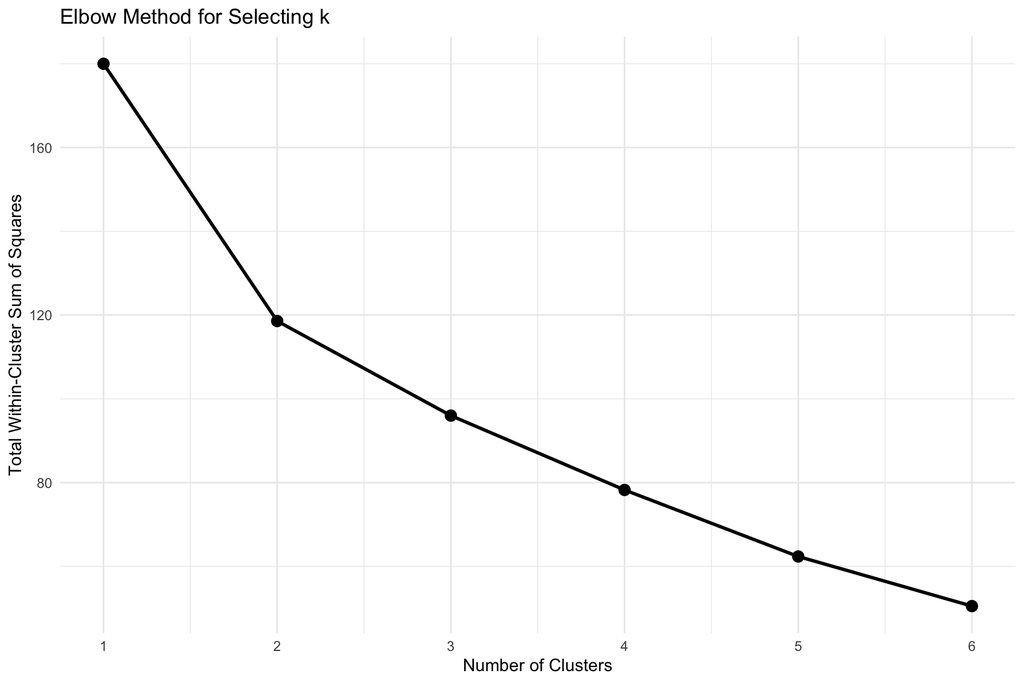

```r
k_values <- 1:6

wss <- sapply(k_values, function(k) {
  set.seed(123)

  kmeans(
    financial_scaled,
    centers = k,
    nstart = 100,
    iter.max = 100
  )$tot.withinss
})

elbow_data <- data.frame(
  Clusters = k_values,
  WSS = wss
)

ggplot(
  elbow_data,
  aes(x = Clusters, y = WSS)
) +
  geom_line(linewidth = 1) +
  geom_point(size = 3) +
  scale_x_continuous(breaks = k_values) +
  labs(
    title = "Elbow Method for Selecting k",
    x = "Number of Clusters",
    y = "Total Within-Cluster Sum of Squares"
  ) +
  theme_minimal()
```

The elbow method evaluates how much within-cluster variation decreases as additional clusters are introduced.

A useful number of clusters is often located near the point where the reduction in within-cluster variation begins to slow.

Because the dataset contains only 21 companies, solutions with two through six clusters are considered. Using too many clusters could produce very small groups that are difficult to interpret.

## 4.2 3.2 Silhouette Analysis

```r
distance_matrix <- dist(financial_scaled)

silhouette_scores <- sapply(2:6, function(k) {
  set.seed(123)

  model <- kmeans(
    financial_scaled,
    centers = k,
    nstart = 100,
    iter.max = 100
  )

  silhouette_result <- silhouette(
    model$cluster,
    distance_matrix
  )

  mean(silhouette_result[, "sil_width"])
})

silhouette_data <- data.frame(
  Clusters = 2:6,
  Average_Silhouette = silhouette_scores
)

kable(
  round(silhouette_data, 3),
  caption = "Average Silhouette Width by Cluster Count"
)
```

Average Silhouette Width by Cluster Count

| Clusters | Average_Silhouette |
| --- | --- |
| 2 | 0.273 |
| 3 | 0.280 |
| 4 | 0.225 |
| 5 | 0.249 |
| 6 | 0.250 |

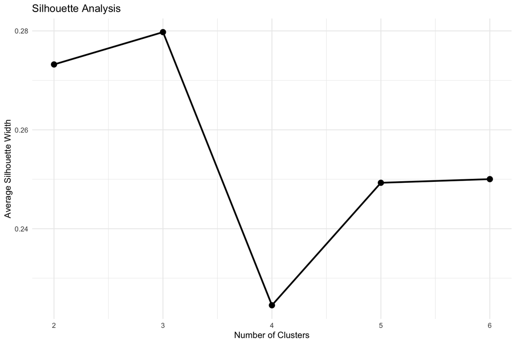

```r
ggplot(
  silhouette_data,
  aes(x = Clusters, y = Average_Silhouette)
) +
  geom_line(linewidth = 1) +
  geom_point(size = 3) +
  scale_x_continuous(breaks = 2:6) +
  labs(
    title = "Silhouette Analysis",
    x = "Number of Clusters",
    y = "Average Silhouette Width"
  ) +
  theme_minimal()
```

Silhouette analysis evaluates the degree to which companies are similar to other companies in their assigned cluster and different from companies in other clusters.

Higher average silhouette values generally indicate more clearly separated clusters.

The elbow and silhouette methods are used together to evaluate the appropriate number of clusters. The silhouette method provides a quantitative comparison, while the elbow method offers a visual assessment of the trade-off between model complexity and within-cluster variation.

## 4.3 3.3 Select the Number of Clusters

```r
best_k <- silhouette_data$Clusters[
  which.max(silhouette_data$Average_Silhouette)
]

cat(
  "Selected number of clusters:",
  best_k,
  "\n"
)
```

```
## Selected number of clusters: 3
```

```r
cat(
  "Average silhouette width:",
  round(max(silhouette_scores), 3),
  "\n"
)
```

```
## Average silhouette width: 0.28
```

The final number of clusters is selected using the highest average silhouette width among the candidate solutions.

This provides an objective selection criterion rather than arbitrarily choosing the number of groups. The elbow plot is also examined as a supporting diagnostic.

The selected number of clusters is **3**, with an average silhouette width of **0.28**.

# 5 4. Perform k-Means Clustering

## 5.1 4.1 Fit the Final Model

```r
set.seed(123)

final_kmeans <- kmeans(
  financial_scaled,
  centers = best_k,
  nstart = 100,
  iter.max = 100
)

pharma$Cluster <- factor(
  final_kmeans$cluster
)

table(pharma$Cluster)
```

```
##
##  1  2  3
##  4 11  6
```

```r
cat(
  "Total within-cluster sum of squares:",
  round(final_kmeans$tot.withinss, 3),
  "\n"
)
```

```
## Total within-cluster sum of squares: 95.994
```

```r
cat(
  "Between-cluster variation proportion:",
  round(
    final_kmeans$betweenss /
      final_kmeans$totss,
    3
  ),
  "\n"
)
```

```
## Between-cluster variation proportion: 0.467
```

The k-means algorithm groups companies by minimizing the sum of squared Euclidean distances between each company and its assigned cluster center.

The analysis uses 100 random starting configurations to reduce sensitivity to the initial placement of cluster centers.

A fixed random seed is also used to make the results reproducible.

## 5.2 4.2 Identify the Companies in Each Cluster

```r
cluster_membership <- pharma[
  ,
  c("Symbol", "Name", "Cluster")
]

cluster_membership <- cluster_membership[
  order(cluster_membership$Cluster),
]

kable(
  cluster_membership,
  caption = "Pharmaceutical Companies by Cluster"
)
```

Pharmaceutical Companies by Cluster

|  | Symbol | Name | Cluster |
| --- | --- | --- | --- |
| 2 | AGN | Allergan, Inc. | 1 |
| 3 | AHM | Amersham plc | 1 |
| 6 | BAY | Bayer AG | 1 |
| 18 | PHA | Pharmacia Corporation | 1 |
| 1 | ABT | Abbott Laboratories | 2 |
| 4 | AZN | AstraZeneca PLC | 2 |
| 7 | BMY | Bristol-Myers Squibb Company | 2 |
| 10 | LLY | Eli Lilly and Company | 2 |
| 11 | GSK | GlaxoSmithKline plc | 2 |
| 13 | JNJ | Johnson & Johnson | 2 |
| 15 | MRK | Merck & Co., Inc. | 2 |
| 16 | NVS | Novartis AG | 2 |
| 17 | PFE | Pfizer Inc | 2 |
| 19 | SGP | Schering-Plough Corporation | 2 |
| 21 | WYE | Wyeth | 2 |
| 5 | AVE | Aventis | 3 |
| 8 | CHTT | Chattem, Inc | 3 |
| 9 | ELN | Elan Corporation, plc | 3 |
| 12 | IVX | IVAX Corporation | 3 |
| 14 | MRX | Medicis Pharmaceutical Corporation | 3 |
| 20 | WPI | Watson Pharmaceuticals, Inc. | 3 |

This table identifies the companies assigned to each cluster. Companies within the same cluster have relatively similar standardized financial characteristics.

# 6 5. Interpret the Financial Clusters

## 6.1 5.1 Average Financial Characteristics

```r
cluster_means <- aggregate(
  financial_data,
  by = list(Cluster = pharma$Cluster),
  FUN = mean
)

kable(
  data.frame(
    Cluster = cluster_means$Cluster,
    round(cluster_means[, -1], 2)
  ),
  caption = "Mean Financial Characteristics by Cluster"
)
```

Mean Financial Characteristics by Cluster

| Cluster | Market_Cap | Beta | PE_Ratio | ROE | ROA | Asset_Turnover | Leverage | Rev_Growth | Net_Profit_Margin |
| --- | --- | --- | --- | --- | --- | --- | --- | --- | --- |
| 1 | 21.75 | 0.60 | 46.90 | 11.3 | 5.10 | 0.75 | 0.30 | 7.01 | 6.65 |
| 2 | 97.11 | 0.43 | 20.95 | 35.7 | 14.95 | 0.80 | 0.33 | 10.16 | 20.17 |
| 3 | 9.23 | 0.65 | 19.43 | 17.3 | 5.98 | 0.48 | 1.25 | 23.49 | 13.52 |

The cluster means allow the financial characteristics of the groups to be compared in their original measurement units.

Differences in market capitalization indicate variation in company size, while differences in return on equity, return on assets, and net profit margin indicate differences in profitability.

Revenue growth, asset turnover, leverage, beta, and price/earnings ratios provide additional information about financial structure, operating performance, risk, and valuation.

## 6.2 5.2 Standardized Cluster Centers

```r
cluster_centers <- as.data.frame(
  final_kmeans$centers
)

cluster_centers$Cluster <- rownames(
  cluster_centers
)

cluster_centers <- cluster_centers[
  ,
  c("Cluster", financial_vars)
]

kable(
  data.frame(
    Cluster = cluster_centers$Cluster,
    round(cluster_centers[, -1], 2)
  ),
  caption = "Standardized Cluster Centers"
)
```

Standardized Cluster Centers

| Cluster | Market_Cap | Beta | PE_Ratio | ROE | ROA | Asset_Turnover | Leverage | Rev_Growth | Net_Profit_Margin |
| --- | --- | --- | --- | --- | --- | --- | --- | --- | --- |
| 1 | -0.61 | 0.27 | 1.31 | -0.96 | -1.02 | 0.23 | -0.36 | -0.58 | -1.38 |
| 2 | 0.67 | -0.36 | -0.28 | 0.66 | 0.83 | 0.46 | -0.33 | -0.29 | 0.68 |
| 3 | -0.83 | 0.48 | -0.37 | -0.56 | -0.85 | -1.00 | 0.85 | 0.92 | -0.33 |

Standardized cluster centers provide a more direct comparison of the relative financial strengths and weaknesses of each group.

Positive standardized values indicate that the cluster average is above the overall dataset average, while negative values indicate that it is below the overall average.

For example, a positive standardized return on assets indicates above-average asset profitability, while a negative standardized market capitalization indicates that the companies in the cluster tend to be smaller than the overall industry sample.

## 6.3 5.3 Visualize Cluster Profiles

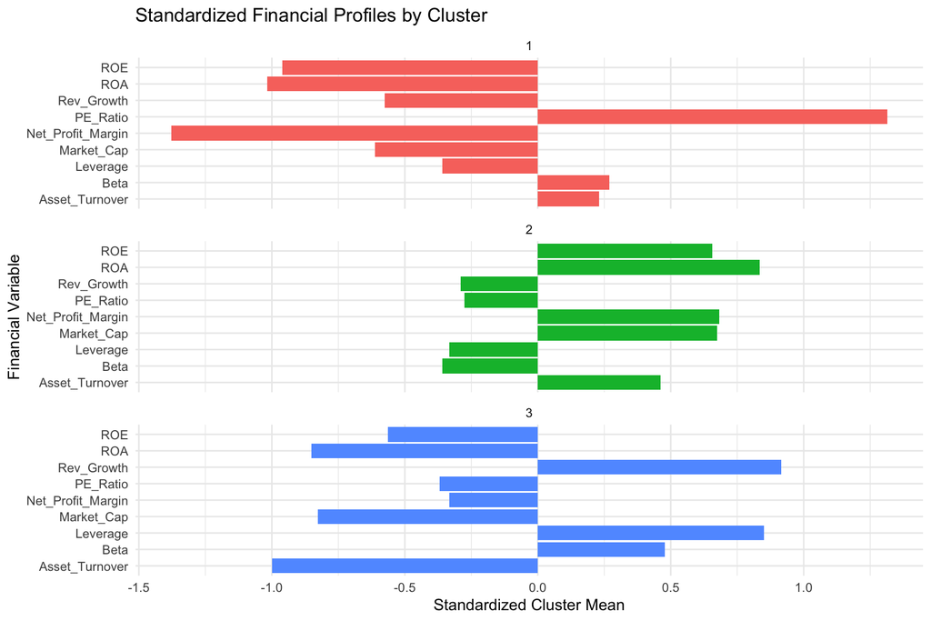

```r
centers_long <- data.frame(
  Cluster = rep(
    rownames(final_kmeans$centers),
    each = length(financial_vars)
  ),
  Variable = rep(
    financial_vars,
    times = best_k
  ),
  Value = as.vector(
    t(final_kmeans$centers)
  )
)

ggplot(
  centers_long,
  aes(
    x = Variable,
    y = Value,
    fill = Cluster
  )
) +
  geom_col() +
  facet_wrap(
    ~ Cluster,
    ncol = 1
  ) +
  coord_flip() +
  labs(
    title = "Standardized Financial Profiles by Cluster",
    x = "Financial Variable",
    y = "Standardized Cluster Mean"
  ) +
  theme_minimal() +
  theme(
    legend.position = "none"
  )
```

The standardized cluster profiles show which financial characteristics distinguish each group from the overall sample.

The most important differences can be identified by examining the largest positive and negative standardized values.

## 6.4 5.4 Identify Distinguishing Characteristics

```r
for (i in seq_len(best_k)) {

  center_values <- final_kmeans$centers[i, ]

  highest <- names(
    sort(
      center_values,
      decreasing = TRUE
    )
  )[1:3]

  lowest <- names(
    sort(
      center_values,
      decreasing = FALSE
    )
  )[1:3]

  cat(
    "\nCluster", i, "\n"
  )

  cat(
    "Companies:",
    sum(final_kmeans$cluster == i),
    "\n"
  )

  cat(
    "Highest relative characteristics:",
    paste(highest, collapse = ", "),
    "\n"
  )

  cat(
    "Lowest relative characteristics:",
    paste(lowest, collapse = ", "),
    "\n"
  )
}
```

```
##
## Cluster 1
## Companies: 4
## Highest relative characteristics: PE_Ratio, Beta, Asset_Turnover
## Lowest relative characteristics: Net_Profit_Margin, ROA, ROE
##
## Cluster 2
## Companies: 11
## Highest relative characteristics: ROA, Net_Profit_Margin, Market_Cap
## Lowest relative characteristics: Beta, Leverage, Rev_Growth
##
## Cluster 3
## Companies: 6
## Highest relative characteristics: Rev_Growth, Leverage, Beta
## Lowest relative characteristics: Asset_Turnover, ROA, Market_Cap
```

This analysis identifies the three financial variables with the highest standardized means and the three with the lowest standardized means for each cluster.

These characteristics provide a basis for describing and naming the clusters.

Because the results are relative to the 21 companies in the dataset, an above-average financial characteristic should not automatically be interpreted as strong performance across the entire pharmaceutical industry.

# 7 6. Visualize the Cluster Assignments

## 7.1 6.1 Principal Component Visualization

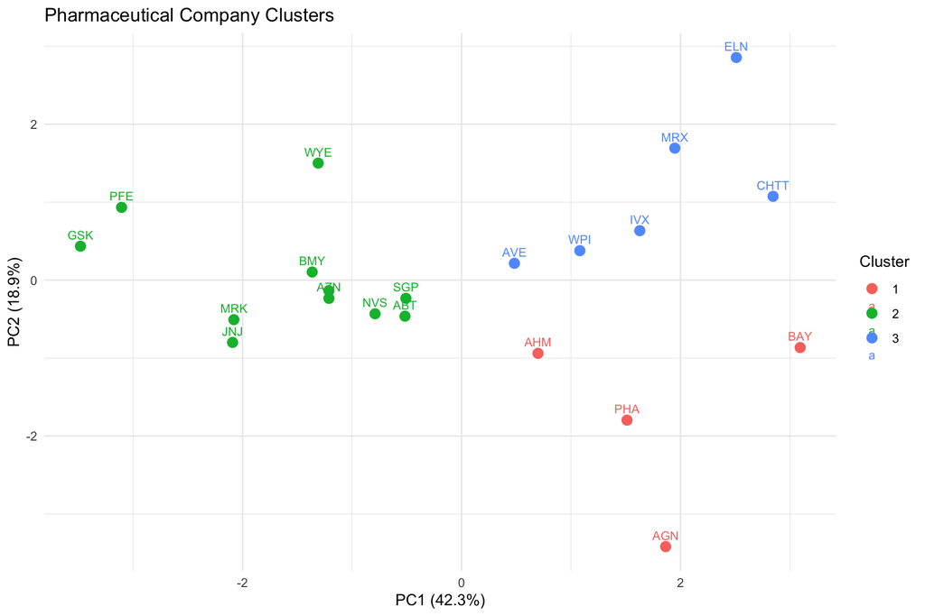

```r
pca_result <- prcomp(
  financial_scaled,
  center = FALSE,
  scale. = FALSE
)

pca_data <- data.frame(
  PC1 = pca_result$x[, 1],
  PC2 = pca_result$x[, 2],
  Cluster = pharma$Cluster,
  Company = pharma$Symbol
)

variance_explained <- (
  pca_result$sdev^2 /
    sum(pca_result$sdev^2)
) * 100

ggplot(
  pca_data,
  aes(
    x = PC1,
    y = PC2,
    color = Cluster
  )
) +
  geom_point(size = 3) +
  geom_text(
    aes(label = Company),
    vjust = -0.8,
    check_overlap = TRUE,
    size = 3
  ) +
  labs(
    title = "Pharmaceutical Company Clusters",
    x = paste0(
      "PC1 (",
      round(variance_explained[1], 1),
      "%)"
    ),
    y = paste0(
      "PC2 (",
      round(variance_explained[2], 1),
      "%)"
    )
  ) +
  theme_minimal()
```

Principal component analysis is used only to visualize the clusters in two dimensions. The actual clustering is performed using all nine standardized financial variables.

The visualization shows the relative positions of companies based on the first two principal components. Companies appearing closer together tend to have more similar financial profiles in this two-dimensional representation.

Because the visualization reduces nine dimensions to two, some differences used in the clustering model may not be visible in the graph.

# 8 7. Examine Variables Excluded from Clustering

The next stage evaluates whether the financial clusters exhibit patterns in three variables that were not used to form the groups:

- Median brokerage recommendation
- Headquarters location
- Stock exchange

These variables provide additional context for interpreting the clusters.

## 8.1 7.1 Brokerage Recommendations

```r
recommendation_table <- table(
  pharma$Cluster,
  pharma$Median_Recommendation
)

kable(
  recommendation_table,
  caption = "Brokerage Recommendations by Cluster"
)
```

Brokerage Recommendations by Cluster

| Hold | Moderate Buy | Moderate Sell | Strong Buy |
| --- | --- | --- | --- |
| 2 | 1 | 0 | 1 |
| 6 | 3 | 2 | 0 |
| 1 | 3 | 2 | 0 |

```r
recommendation_percent <- prop.table(
  recommendation_table,
  margin = 1
) * 100

kable(
  round(recommendation_percent, 1),
  caption = "Brokerage Recommendations by Cluster (%)"
)
```

Brokerage Recommendations by Cluster (%)

| Hold | Moderate Buy | Moderate Sell | Strong Buy |
| --- | --- | --- | --- |
| 50.0 | 25.0 | 0.0 | 25 |
| 54.5 | 27.3 | 18.2 | 0 |
| 16.7 | 50.0 | 33.3 | 0 |

The recommendation tables show how brokerage opinions are distributed across the financial clusters.

If a cluster contains a relatively high proportion of favorable recommendations, this may indicate that analysts view companies with those financial characteristics more positively.

However, recommendations are categorical labels rather than continuous numerical measures. They are therefore evaluated through frequency distributions rather than by calculating numerical averages.

## 8.2 7.2 Headquarters Location

```r
location_table <- table(
  pharma$Cluster,
  pharma$Location
)

kable(
  location_table,
  caption = "Headquarters Location by Cluster"
)
```

Headquarters Location by Cluster

| CANADA | FRANCE | GERMANY | IRELAND | SWITZERLAND | UK | US |
| --- | --- | --- | --- | --- | --- | --- |
| 1 | 0 | 1 | 0 | 0 | 1 | 1 |
| 0 | 0 | 0 | 0 | 1 | 2 | 8 |
| 0 | 1 | 0 | 1 | 0 | 0 | 4 |

```r
location_percent <- prop.table(
  location_table,
  margin = 1
) * 100

kable(
  round(location_percent, 1),
  caption = "Headquarters Location by Cluster (%)"
)
```

Headquarters Location by Cluster (%)

| CANADA | FRANCE | GERMANY | IRELAND | SWITZERLAND | UK | US |
| --- | --- | --- | --- | --- | --- | --- |
| 25 | 0.0 | 25 | 0.0 | 0.0 | 25.0 | 25.0 |
| 0 | 0.0 | 0 | 0.0 | 9.1 | 18.2 | 72.7 |
| 0 | 16.7 | 0 | 16.7 | 0.0 | 0.0 | 66.7 |

Headquarters location is examined to determine whether companies with similar financial characteristics are concentrated in particular countries.

A concentration of companies from one country within a cluster could suggest geographic similarities in financial structure or business operations.

However, the small dataset does not establish that geographic location causes the observed financial similarities.

## 8.3 7.3 Stock Exchange

```r
exchange_table <- table(
  pharma$Cluster,
  pharma$Exchange
)

kable(
  exchange_table,
  caption = "Stock Exchange by Cluster"
)
```

Stock Exchange by Cluster

| AMEX | NASDAQ | NYSE |
| --- | --- | --- |
| 0 | 0 | 4 |
| 0 | 0 | 11 |
| 1 | 1 | 4 |

```r
exchange_percent <- prop.table(
  exchange_table,
  margin = 1
) * 100

kable(
  round(exchange_percent, 1),
  caption = "Stock Exchange by Cluster (%)"
)
```

Stock Exchange by Cluster (%)

| AMEX | NASDAQ | NYSE |
| --- | --- | --- |
| 0.0 | 0.0 | 100.0 |
| 0.0 | 0.0 | 100.0 |
| 16.7 | 16.7 | 66.7 |

Stock exchange membership is examined to determine whether companies listed on the same exchange tend to share similar financial characteristics.

A concentration within a cluster could indicate an association between listing venue and financial profile.

However, an association would not necessarily imply that the stock exchange itself influences financial performance.

## 8.4 7.4 Visualize Recommendation Patterns

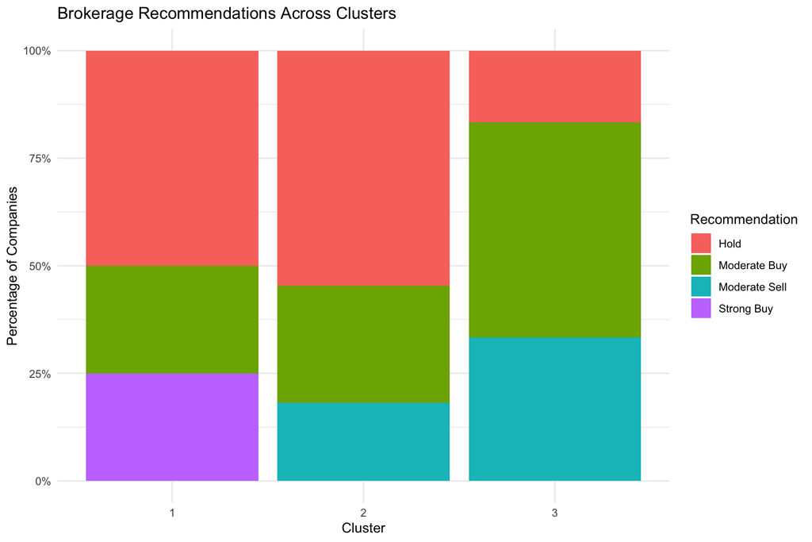

```r
ggplot(
  pharma,
  aes(
    x = Cluster,
    fill = Median_Recommendation
  )
) +
  geom_bar(
    position = "fill"
  ) +
  scale_y_continuous(
    labels = function(x) {
      paste0(round(x * 100), "%")
    }
  ) +
  labs(
    title = "Brokerage Recommendations Across Clusters",
    x = "Cluster",
    y = "Percentage of Companies",
    fill = "Recommendation"
  ) +
  theme_minimal()
```

This chart displays the proportion of brokerage recommendations within each cluster.

The graph complements the frequency tables by making differences in the composition of the groups easier to identify.

# 9 8. Name and Describe the Clusters

## 9.1 8.1 Generate Descriptive Cluster Names

```r
make_cluster_name <- function(center) {

  profitability <- mean(
    center[c(
      "ROE",
      "ROA",
      "Net_Profit_Margin"
    )]
  )

  growth <- center["Rev_Growth"]
  size <- center["Market_Cap"]
  risk <- center["Beta"]

  if (
    profitability > 0.4 &&
    growth > 0
  ) {
    return("High-Profit Growth Firms")
  }

  if (
    profitability > 0.4
  ) {
    return("Profitability Leaders")
  }

  if (
    size > 0.4 &&
    profitability >= 0
  ) {
    return("Large Established Firms")
  }

  if (
    growth > 0.4
  ) {
    return("Growth-Oriented Firms")
  }

  if (
    risk > 0.4
  ) {
    return("Higher-Risk Firms")
  }

  if (
    profitability < -0.4
  ) {
    return("Lower-Profit Firms")
  }

  return("Balanced Financial Firms")
}

cluster_names <- sapply(
  seq_len(best_k),
  function(i) {
    make_cluster_name(
      final_kmeans$centers[i, ]
    )
  }
)

names(cluster_names) <- as.character(
  seq_len(best_k)
)

cluster_name_table <- data.frame(
  Cluster = seq_len(best_k),
  Cluster_Name = unname(cluster_names),
  Number_of_Companies = as.vector(
    table(pharma$Cluster)
  )
)

kable(
  cluster_name_table,
  caption = "Descriptive Cluster Names"
)
```

Descriptive Cluster Names

| Cluster | Cluster_Name | Number_of_Companies |
| --- | --- | --- |
| 1 | Lower-Profit Firms | 4 |
| 2 | Profitability Leaders | 11 |
| 3 | Growth-Oriented Firms | 6 |

Cluster names are based on the standardized financial characteristics of each group.

Names emphasize the most prominent aspects of financial performance, such as profitability, growth, size, or market risk.

These labels are descriptive interpretations rather than official industry classifications. They should be evaluated alongside the financial cluster means to determine whether they accurately summarize each group’s characteristics.

## 9.2 8.2 Summarize Each Cluster

```r
for (i in seq_len(best_k)) {

  members <- pharma$Name[
    pharma$Cluster == as.character(i)
  ]

  cat(
    "\n\nCluster", i, ":",
    cluster_names[i],
    "\n"
  )

  cat(
    "Number of companies:",
    length(members),
    "\n"
  )

  cat(
    "Companies:",
    paste(members, collapse = "; "),
    "\n"
  )

  means <- cluster_means[
    cluster_means$Cluster == as.character(i),
    financial_vars,
    drop = FALSE
  ]

  cat(
    "Average market capitalization:",
    round(means$Market_Cap, 2),
    "billion dollars\n"
  )

  cat(
    "Average ROE:",
    round(means$ROE, 2),
    "\n"
  )

  cat(
    "Average ROA:",
    round(means$ROA, 2),
    "\n"
  )

  cat(
    "Average revenue growth:",
    round(means$Rev_Growth, 2),
    "\n"
  )

  cat(
    "Average net profit margin:",
    round(means$Net_Profit_Margin, 2),
    "\n"
  )
}
```

```
##
##
## Cluster 1 : Lower-Profit Firms
## Number of companies: 4
## Companies: Allergan, Inc.; Amersham plc; Bayer AG; Pharmacia Corporation
## Average market capitalization: 21.75 billion dollars
## Average ROE: 11.3
## Average ROA: 5.1
## Average revenue growth: 7.01
## Average net profit margin: 6.65
##
##
## Cluster 2 : Profitability Leaders
## Number of companies: 11
## Companies: Abbott Laboratories; AstraZeneca PLC; Bristol-Myers Squibb Company; Eli Lilly and Company; GlaxoSmithKline plc; Johnson & Johnson; Merck & Co., Inc.; Novartis AG; Pfizer Inc; Schering-Plough Corporation; Wyeth
## Average market capitalization: 97.11 billion dollars
## Average ROE: 35.7
## Average ROA: 14.95
## Average revenue growth: 10.16
## Average net profit margin: 20.17
##
##
## Cluster 3 : Growth-Oriented Firms
## Number of companies: 6
## Companies: Aventis; Chattem, Inc; Elan Corporation, plc; IVAX Corporation; Medicis Pharmaceutical Corporation; Watson Pharmaceuticals, Inc.
## Average market capitalization: 9.23 billion dollars
## Average ROE: 17.3
## Average ROA: 5.98
## Average revenue growth: 23.49
## Average net profit margin: 13.52
```

This section provides a company-level summary of each cluster, including its descriptive name, member companies, and major financial characteristics.

The cluster names should be interpreted using the actual financial averages and standardized centers rather than relying exclusively on the automated labels.

# 10 9. Overall Discussion

The k-means analysis provides a systematic approach to identifying financial similarities among pharmaceutical companies.

The clustering process uses nine standardized financial variables, allowing companies to be compared without giving disproportionate influence to measures with larger numerical scales.

The selected number of clusters is **3**, based on the highest average silhouette width among the evaluated solutions.

The analysis highlights how pharmaceutical companies can differ in market capitalization, valuation, profitability, risk, operational efficiency, financial leverage, and expected growth.

The examination of brokerage recommendations, headquarters locations, and stock exchanges provides additional information about the composition of the clusters. Because these variables were excluded from the clustering algorithm, any observed relationships offer an independent descriptive perspective on the financial groupings.

Several limitations should be considered. First, the dataset contains only 21 companies, which limits the generalizability of the results. Second, k-means is sensitive to outliers and the choice of distance measure. Third, the use of equal variable weights assumes that each financial measure is equally relevant to the clustering objective. Finally, the cluster assignments describe similarities rather than causal relationships.

# 11 10. Conclusion

This assignment demonstrates how k-means clustering can be used to explore the financial structure of the pharmaceutical industry.

By standardizing nine financial measures, evaluating alternative numbers of clusters, and applying k-means, the analysis identifies groups of companies with similar financial profiles.

The resulting groups are interpreted through their average financial characteristics and supplemented by comparisons of brokerage recommendations, headquarters locations, and stock exchanges.

The findings illustrate the value of unsupervised machine learning for exploratory financial analysis. Cluster analysis can help an equities analyst organize a complex dataset, identify differences among companies, and develop questions for further investigation.

The results should be treated as an exploratory analytical tool rather than as direct investment recommendations.